# Appendix C: Bayes factor design analysis for SP13 replication

[Guillermo Montero-Melis](https://www.mpi.nl/people/montero-melis-guillermo)

16/02/2020

# 1 Introduction

This knitr script executes and reports a Bayes factor design analysis for our replication of Shebani and Pulvermüller (2013, *Cortex*), henceforth SP13.

This document complements our manuscript submitted as a Registered Report to *Cortex*. See end of document for session info, including package versions, etc. and the manuscript for further context.

## 1.1 General approach

We adopt the following approach for our Bayes factor design analysis (see Schönbrodt and Wagenmakers, 2017, *Psychon Bull Rev*):

1. Simulate data sets with parameters obtained from the analysis of the original data and other parameters estimated from pilot data.
2. Fit two logisic mixed models to each data set using `lme4`, one that includes the critical interaction effect as a population-level (fixed) effect and another that does not.
3. Compute a Bayes factor for the alternative hypothesis (H1: there is an effect) vs the null hypothesis (H0: there is no effect) using the Bayesian information criterion (BIC) of each of the models (see [this link](https://rpubs.com/lindeloev/bayes_factors) for the exact approach).
4. Repeat steps 1-3 a large number of times for different sample sizes and for a scenario in which the critical effect is zero (Type 1 simulations) and a scenario where the critical effect exists (Type 2 simulations).

## 1.2 About the parameters of our statistical generative model

Data simulations are based on our re-analysis of the original data as shared by SP13. Since that data set did not consist of trial-level observations, we do not have a way to estimate item-level variability from it. We therefore use our own pilot data to estimate item-level variability (details below). We assume a generative model for the simulations that mimicks our own experimental setup. Each participant generates data for the four experimental cells defined by our 2x2 design with the following factors:

- Word type: arm words vs leg words
- Interference Movement: arm vs foot movement

There are 104 items (52 arm and 52 leg words) in our study, so we simulate 208 observations per participant. Each data set is randomly generated under a probabilistic binomial (Bernoulli) hierarchical model in which the log-odds of producing an error are a function of the population-level (fixed) effects predictors Interference Movement (arm movements vs. leg movements), Word Type (arm-related vs leg-related words), and their interaction. In addition, random effects variance was added by participants (for intercepts and all the fixed effects and interaction slopes) and items (for intercepts and slopes for Interference Movement). The simulations cross the following factors:

1. Participant sample size: N=15, 60, 108; that is, the original sample size, $N_{min}$, and $N_{max}$, respectively.
2. Simulation type: Type 1 (critical population-level effect set to zero), type 2 (critical population-level effect sampled from the model of the original data).

# 2 Setup workspace

```r
library("knitr")
library("tidyverse")  # ggplot2, dplyr, readr, purrr, etc
library("broom")
library("boot")       # for inv.logit()
library("lme4")
library("brms")
library("tictoc")
library("ggpubr")
library("foreach")     # to parallelize simulations
library("doParallel")  # to parallelize simulations
```

```r
# Global plotting parameters
myalpha <- 0.005  # works for 10k simulations; increase if using less simulations.
jitter_colour <- "dodgerblue3"
theme_set(theme_bw())
```

```r
# Load original data from SP13
d <- read_csv("data/SP13_orig-data_total-errors_long-format.csv") %>%
  # keep critical interference conditions only
  filter(movement %in% c("arm_paradi", "leg_paradi"))
# For each experimental cell, the maximum number of errors is 48 (see
# "Appendix_B_reanalysis_original.Rmd" for justification0)
d$n <- 48
```

# 3 Model of original data

The model takes some time to fit with `brms`, so retrieve it from disk:

```r
# Load from disk - list containing 1) full model, 2) null model, 3) BF
bfm_max <- read_rds("data/sp13_bfm_max.rds")
```

```r
bfm_full <- bfm_max[[1]]
summary(bfm_full)
```

```
##  Family: binomial
##   Links: mu = logit
## Formula: errors | trials(n) ~ 1 + mv + wt + mv_wt + (1 + mv + wt + mv_wt | subject)
##    Data: df (Number of observations: 60)
## Samples: 4 chains, each with iter = 15000; warmup = 2000; thin = 1;
##          total post-warmup samples = 52000
##
## Group-Level Effects:
## ~subject (Number of levels: 15)
##                      Estimate Est.Error l-95% CI u-95% CI Rhat Bulk_ESS
## sd(Intercept)            0.81      0.20     0.52     1.28 1.00    17119
## sd(mv)                   0.35      0.10     0.20     0.58 1.00    21811
## sd(wt)                   0.09      0.06     0.00     0.24 1.00    20276
## sd(mv_wt)                0.07      0.05     0.00     0.19 1.00    26828
## cor(Intercept,mv)        0.13      0.28    -0.44     0.64 1.00    36169
## cor(Intercept,wt)        0.12      0.41    -0.71     0.82 1.00    69247
## cor(mv,wt)               0.23      0.40    -0.64     0.87 1.00    51229
## cor(Intercept,mv_wt)     0.11      0.43    -0.74     0.85 1.00    72197
## cor(mv,mv_wt)            0.01      0.42    -0.78     0.79 1.00    65808
## cor(wt,mv_wt)           -0.06      0.45    -0.84     0.78 1.00    39934
##                      Tail_ESS
## sd(Intercept)           27439
## sd(mv)                  33225
## sd(wt)                  23872
## sd(mv_wt)               27930
## cor(Intercept,mv)       37698
## cor(Intercept,wt)       36966
## cor(mv,wt)              36582
## cor(Intercept,mv_wt)    35176
## cor(mv,mv_wt)           39237
## cor(wt,mv_wt)           41143
##
## Population-Level Effects:
##           Estimate Est.Error l-95% CI u-95% CI Rhat Bulk_ESS Tail_ESS
## Intercept    -0.86      0.22    -1.31    -0.43 1.00    11207    19539
## mv            0.02      0.10    -0.19     0.22 1.00    25245    31146
## wt           -0.05      0.05    -0.16     0.05 1.00    56119    37882
## mv_wt         0.15      0.05     0.05     0.24 1.00    66705    38710
##
## Samples were drawn using sampling(NUTS). For each parameter, Eff.Sample
## is a crude measure of effective sample size, and Rhat is the potential
## scale reduction factor on split chains (at convergence, Rhat = 1).
```

# 4 Power simulations

## 4.1 Prepare data generating process

### 4.1.1 Load function

Load the function that generates binomial data for our design.

```r
source("generate_data_fnc.R")
```

### 4.1.2 Set up simulation parameters

We take our simulation parameters from the statistical model fit to the original data. Next we put these parameters into the right format for our `simulate_binom()` function:

```r
# Fixed (i.e., population-level) effects:
fixef(bfm_full)
```

```
##              Estimate  Est.Error       Q2.5       Q97.5
## Intercept -0.86458049 0.21966535 -1.3073151 -0.43108024
## mv         0.01715228 0.10360703 -0.1914974  0.22085650
## wt        -0.05333050 0.05138847 -0.1561496  0.04765609
## mv_wt      0.14586369 0.04829117  0.0499897  0.24012152
```

```r
# Vector of coefficient means for fixed effects
fixef_means <- fixef(bfm_full)[, 1]
fixef_means
```

```
##   Intercept          mv          wt       mv_wt
## -0.86458049  0.01715228 -0.05333050  0.14586369
```

```r
# SEMs for fixed effects. These we take from the covariance matrix (Sigma) of
# the model. Note we need to square the SEMs to convert them to variances, which
# is what our simulate_binom() function expects (rather than SD).
fixef_sigma <- diag(fixef(bfm_full)[, 2] ^ 2)  # we assume uncorrelated diagonal matrix
fixef_sigma
```

```
##            [,1]       [,2]        [,3]        [,4]
## [1,] 0.04825286 0.00000000 0.000000000 0.000000000
## [2,] 0.00000000 0.01073442 0.000000000 0.000000000
## [3,] 0.00000000 0.00000000 0.002640774 0.000000000
## [4,] 0.00000000 0.00000000 0.000000000 0.002332037
```

```r
# By-subject random effects for the model:
VarCorr(bfm_full)$subject$sd
```

```
##             Estimate  Est.Error        Q2.5     Q97.5
## Intercept 0.81197051 0.19692660 0.518310920 1.2788021
## mv        0.34912933 0.09571024 0.200702915 0.5756546
## wt        0.08992448 0.06241663 0.004097095 0.2352066
## mv_wt     0.06787147 0.05198945 0.002839334 0.1928925
```

```r
# Extract by-subject random SDs and square them to obtain variances:
ranef_sigma_subj <- diag(VarCorr(bfm_full)$subject$sd[, 1]) ^ 2
ranef_sigma_subj
```

```
##           [,1]      [,2]        [,3]        [,4]
## [1,] 0.6592961 0.0000000 0.000000000 0.000000000
## [2,] 0.0000000 0.1218913 0.000000000 0.000000000
## [3,] 0.0000000 0.0000000 0.008086413 0.000000000
## [4,] 0.0000000 0.0000000 0.000000000 0.004606536
```

The original data consists of aggregated by-subject data, not trial-level data. To obtain estimates for item-level variability we use our own pilot data (see [here](https://github.com/montero-melis/2018_replication_sheb-pulv2013/blob/master/1806_pilot_analysis/item-variance_estimates.R)).

```r
# The random by-item intercept is SD=0.65. However, we don't have estimates for
# by-item random slope for movement because we only ran the control condition in
# the pilot. We will assume the SD for this random slope to be the same as the
# by-subject SD for the slope of the critical interaction, which is likely to be
# an overestimate. If so, it will only make our power estimates more conservative:
ranef_sigma_item <- diag(c(0.65, 0.06)) ^ 2  # square to obtain variances
ranef_sigma_item
```

```
##        [,1]   [,2]
## [1,] 0.4225 0.0000
## [2,] 0.0000 0.0036
```

### 4.1.3 Example simulation

We can now call the `simulate_binom` function to generate data:

```r
set.seed(753)
sim_ex <- simulate_binom(
  Nsubj = 10,
  Nitem = 24,
  fixef_means = fixef_means,
  fixef_sigma = fixef_sigma,
  ranef_sigma_subj = ranef_sigma_subj,
  ranef_sigma_item = ranef_sigma_item
  )
sim_ex
```

```
## # A tibble: 480 x 14
## # Groups:   subject, trial_in_exp [120]
##    subject block trial_in_exp movement word_type  item pos_in_trial
##      <int> <dbl>        <dbl> <fct>    <fct>     <int>        <int>
##  1       1     1            1 arms     leg-word     17            1
##  2       1     1            1 arms     leg-word     19            2
##  3       1     1            1 arms     leg-word     22            3
##  4       1     1            1 arms     leg-word     23            4
##  5       1     1            2 arms     leg-word     24            1
##  6       1     1            2 arms     leg-word     18            2
##  7       1     1            2 arms     leg-word     20            3
##  8       1     1            2 arms     leg-word     14            4
##  9       1     1            3 arms     arm-word     10            1
## 10       1     1            3 arms     arm-word      1            2
## # ... with 470 more rows, and 7 more variables: preced_error <dbl>,
## #   Error <int>, LO_fixef <dbl>, LO_subj <dbl>, LO_item <dbl>, LO <dbl>,
## #   prob <dbl>
```

## 4.2 Functions to analyze simulations

### 4.2.1 Basic function

```r
analyze_simulation <- function(df, print_model_summaries = FALSE) {

  # start counter
  tic()

  # Contrast coding (umeric coding allows for models without RE correlations)
  df$mv <- scale(as.numeric(df$movement), scale = FALSE) * -2
  df$wt <- scale(as.numeric(df$word_type), scale = FALSE) * -2
  df$mv_wt <- df$mv * df$wt

  # function to catch convergence issues
  converge <- function (fm) {
  # Paste in case there are several messages
  message <- paste(summary(fm)$optinfo$conv$lme4$messages, collapse = " / ")
  if( is.null(message) ) { "" } else { message }
  }

  # Function to fit a full and null model given model formula as string:
  fit_formula <- function (f_str, d = df) {
    formula <- as.formula(f_str)  # convert to formula
    full <- glmer(formula, data = d,
                  control = glmerControl(optCtrl=list(maxfun=1e6)),
                  family = "binomial"
                  )
    null <- update(full, formula = ~ . - mv_wt)

    if (print_model_summaries) {
      print(summary(full))
      print(summary(null))
    }
    list(full, null)
  }

  # Fit models without RE correlations using double-bar syntax
  # (see Reinhold Kliegl's post: https://rpubs.com/Reinhold/391071)
  myf <- "Error ~ mv + wt + mv_wt + (1 + mv + wt + mv_wt || subject) + (1 + mv || item)"
  models <- fit_formula(myf)

  # Put fixed effect model coefficients into one data frame
  model_info <- bind_rows(
    unnest(tidy(models[[1]])) %>%
      mutate(model = "full", convergence = converge(models[[1]])),
    unnest(tidy(models[[2]])%>% filter(group == "fixed" | grepl("mv_wt", term))) %>%
      mutate(model = "null", convergence = converge(models[[2]]))
  ) %>%
    # Now add more concise info (redundantly repeated across rows, can be filtered
    # out later):
    mutate(
      BIC_full = BIC(models[[1]]),
      BIC_null = BIC(models[[2]]),
      BF_BIC = exp( (BIC(models[[2]]) - BIC(models[[1]]) ) / 2),
      conv_full = converge(models[[1]]),
      conv_null = converge(models[[2]]),
      formula_full = myf
    ) %>%
    select(-group)
  # Add the time it took
  mytoc <- toc()
  model_info$t_ellapsed <- mytoc$toc - mytoc$tic
  model_info
}
```

Let’s illustrate with an example (using the data set simulated above).

```r
set.seed(753)
tictoc::tic()
# print_model_summaries=TRUE would print the actual model summaries to screen
an_ex <- analyze_simulation(sim_ex, print_model_summaries = FALSE)
```

```
## 7.88 sec elapsed
```

```r
tictoc::toc()
```

```
## 7.93 sec elapsed
```

The output is a data frame with information about the analysis of the simulated data set. Note that the first columns are unique (they are about parameter estimates in the model), but starting from the convergence column the info is repeated across rows. We will mostly use results from the BIC of every model but all the other output is good to keep to better understand what is going on and what the actual parameter estimates are for the different models:

```r
kable(head(an_ex, 3))
```

| term | estimate | std.error | statistic | p.value | model | convergence | BIC_full | BIC_null | BF_BIC | conv_full | conv_null | formula_full | t_ellapsed |
| --- | --- | --- | --- | --- | --- | --- | --- | --- | --- | --- | --- | --- | --- |
| (Intercept) | -1.0254711 | 0.3880233 | -2.6428082 | 0.0082222 | full | Model failed to converge with max\|grad\| = 0.00352704 (tol = 0.001, component 1) | 587.8832 | 582.3737 | 0.0636253 | Model failed to converge with max\|grad\| = 0.00352704 (tol = 0.001, component 1) | Model failed to converge with max\|grad\| = 0.00805014 (tol = 0.001, component 1) | Error ~ mv + wt + mv_wt + (1 + mv + wt + mv_wt \|\| subject) + (1 + mv \|\| item) | 7.88 |
| mv | 0.4112536 | 0.1811249 | 2.2705527 | 0.0231741 | full | Model failed to converge with max\|grad\| = 0.00352704 (tol = 0.001, component 1) | 587.8832 | 582.3737 | 0.0636253 | Model failed to converge with max\|grad\| = 0.00352704 (tol = 0.001, component 1) | Model failed to converge with max\|grad\| = 0.00805014 (tol = 0.001, component 1) | Error ~ mv + wt + mv_wt + (1 + mv + wt + mv_wt \|\| subject) + (1 + mv \|\| item) | 7.88 |
| wt | 0.1123753 | 0.1919078 | 0.5855693 | 0.5581650 | full | Model failed to converge with max\|grad\| = 0.00352704 (tol = 0.001, component 1) | 587.8832 | 582.3737 | 0.0636253 | Model failed to converge with max\|grad\| = 0.00352704 (tol = 0.001, component 1) | Model failed to converge with max\|grad\| = 0.00805014 (tol = 0.001, component 1) | Error ~ mv + wt + mv_wt + (1 + mv + wt + mv_wt \|\| subject) + (1 + mv \|\| item) | 7.88 |

### 4.2.2 Function to analyze many data sets

The following function does the basic work: It is designed to be applied with `purrr::pmap` together with a data frame where each row passes the relevant parameters that vary across simulations (`Nsubj` and `sim_type`), alon with the random seed (`rseed`) to make the simulations reproducible, and yet some other information (like `incl_col_names`) which are needed for the functions to combine together in the intended way.

Note that this function directly writes simulation results to a file on disk, appending new simulation results to whatever already is on the file. This is better than generating an R object in the current session: since the simulations can take days or weeks, writing to disk makes it possible to break the process at any point and resume the simulations later.

```r
sim_many <- function(rseed, sim_id, Nsubj, sim_type, incl_col_names, ...) {
  istype1 <- if (sim_type == "type2") {
    FALSE
    } else if (sim_type == "type1") {
    TRUE
    } else{
        stop("sim_type has to be either 'type1' or 'type2'")
    }
  set.seed(rseed)
  df <- simulate_binom(Nsubj, type1 = istype1, ...)
  result <- analyze_simulation(df)
  result$sim_id   <- sim_id
  result$rseed    <- rseed
  result$sim_type <- sim_type
  result$Nsubj    <- Nsubj
  write_csv(
    result,
    path = "data/power_simulation_results_append.csv",
    col_names = incl_col_names,  # only needed first time it's run
    append = TRUE)
  result
}
```

### 4.2.3 Function to tally the simulations left to run

A function that computes how many simulations we still need to run, based on the file on disk that stores simulation results. It outputs FALSE if it doesn’t find the file. This function is called from the `run_till_aim()` function (below) which actually runs the simulations.

```r
sim_till_aim <- function(
  aim,
  filter_out_nsubj = 0,  # by default this will consider all sample sizes
  filter_out_type = ""   # by default it will consider type1 and type2
  ) {
  neg2zero <- function(x) ifelse(x < 0, 0, x)  # little trick needed below
  # retrieve simulations and check which ones converged (both null and full)
  if (file.exists("data/power_simulation_results_append.csv")) {
    sims <- read_csv("data/power_simulation_results_append.csv")
  } else {
    return (FALSE)
  }
  # If there are simulations, get the right info about convergence etc
  sims <- sims %>%
    select(rseed, Nsubj, sim_type, conv_full, conv_null) %>% unique() %>%
    mutate(
      converged = ( is.na(conv_full) & is.na(conv_null) ),
      Nsubj = as.numeric(Nsubj)
      ) %>%
    group_by(Nsubj, sim_type) %>%
    summarise(sims_run = n(), converged = sum(converged)) %>%
    mutate(
      aim = aim,
      needed_neg = aim - converged,
      needed = neg2zero(needed_neg)) %>%
    # Estimated convergence rate at different sample sizes
    left_join(tibble(
      Nsubj =     c(15,   60,   96,   102,  108),
      conv_rate = c(0.13, 0.40, 0.55, 0.56, 0.59))
      ) %>%
    mutate(nsims = round(needed / conv_rate)) %>%
    filter(
      (! Nsubj %in% filter_out_nsubj),
      (sim_type != filter_out_type)
      )
  sims
}
```

### 4.2.4 Wrapper function

We need a wrapper function that generates data sets with different simulation parameters (different sample sizes and either Type 1 or Type 2 simulations), analyzes the data sets and stores the result. This function will run until a pre-specified aim of *converged* models. (Note that models may not always converge, which is especially frequent when sample sizes are small).

Note again that it doesn’t generate output to the console. Instead it writes the results to file (because it calls `sim_many()` and that is what `sim_many()` does, see above).

```r
# Function checks how many converged simulations there are and runs new
# ones until aim is reached. Note the function is parallelized to run faster.
run_till_aim <- function(
  aim,  # the number of converged models we want for each sample size (type1/2)
  sample_sizes = c(15, 60, 108),
  nb_cores = parallel::detectCores(),  # Number of cores used in parallelization
  ...
  ) {
  tictoc::tic()  # start counter
  sims <- sim_till_aim(aim, ...)  # nb of simulations left

  # 1st case: no simulations have been run, in which case sims is FALSE
  if (is.logical(sims)) {
    # so then run we'll run one of each sample size to get started
    print("Create file and run one type1 and type2 sim for each sample size")
    params <- tibble(
      Nsubj = rep(sample_sizes, each = 2),
      sim_type = rep(c("type2", "type1"), length.out = 2 * length(sample_sizes))
      )
    # include col names 1st time
    params$incl_col_names <- c(TRUE, rep(FALSE, nrow(params) - 1))
    params$rseed <- sample.int(10 ^ 9, size = nrow(params))  # random seeds
    params$sim_id <- seq_len(nrow(params))
    print("We'll now run:")
    print(params)
    # We can't parellize it yet, bc we want column names to be in row 1:
    purrr::pmap(
      .l = params,
      .f = sim_many,
      # fixed simulation parameters (for clarity, comment out those passed in params)
      # Nsubj =,
      Nitem = 104,
      fixef_means = fixef_means,
      fixef_sigma = fixef_sigma,
      ranef_sigma_subj = ranef_sigma_subj,
      ranef_sigma_item = ranef_sigma_item
    )

    } else {  # So there is already a file...
      # Check if we have attained the aim
      if (sum(sims$nsims) == 0) {
        return("Done, my friend!!!")
      }
      # There are simulations but we haven't reached the aim.
      # Print how many simulations will be run:
      print("We'll now run:")
      print(sims)
      # set up parameters
      params <- tibble(
        rseed = sample.int(10 ^ 9, size = sum(sims$nsims)),
        Nsubj = rep(sims$Nsubj, sims$nsims),
        sim_type = rep(sims$sim_type, sims$nsims),
        incl_col_names = FALSE
      )
      params$sim_id <- seq_len(nrow(params))

      # Now we can parallelize!
      registerDoParallel(nb_cores)  # use multicore, by default uses all available
      foreach (
        i = 1:nrow(params),
        .packages = c("tidyverse", "broom", "lme4", "mvtnorm", "boot", "tictoc"),
        .export = c(
          "sim_many", "simulate_binom", "analyze_simulation", "fixef_means",
          "fixef_sigma", "ranef_sigma_subj", "ranef_sigma_item"
          )
        ) %dopar% {
          purrr::pmap(
            .l = params[i,],
            .f = sim_many,
            # fixed simulation parameters (for clarity, comment out those passed in params)
            # Nsubj =,
            Nitem = 104,
            fixef_means = fixef_means,
            fixef_sigma = fixef_sigma,
            ranef_sigma_subj = ranef_sigma_subj,
            ranef_sigma_item = ranef_sigma_item
          )
        }
      }
  tictoc::toc()  # stop counter
  # recursively runs itself until aim is reached
  run_till_aim(aim, ...)
}
```

## 4.3 Run the simulations (generate and analyze data sets)

The following code will run the simulations until there are as many converged simulations of each type as specified in the `aim` argument. Note that running 1000 simulations could take several days on a normal computer. Running 10 000 as we did is only recommended on a computer cluster.

```r
# sim_till_aim(aim = 1000)  # Outputs FALSE if there isn't any file on disk yet
# run_till_aim(aim = 1000)
```

# 5 Basic descriptors of simulations and processing

## 5.1 Load simulations from disk and split into two data frames

Once the simulations have run, we load results from disk.

Note that we generate the report based on the full set of at least 10,000 simulations per sample size and simulation type. However, the corresponding data file is too large to share. If you want to run the script, you should either generate your own simulations (see previous section) or use the lite version shared in this git repo. You will have to comment/uncomment appropriately from the following snippet.

```r
# # This is the file that keeps stacking the result of simulations:
# mysims <- read_csv("data/power_simulation_results_append.csv")
# # But we can also load a lite version of previously run simulations, with 5% of
# # the final simulations (randomly chosen):
# mysims <- read_csv("data/power_simulation_results_append_lite.csv")
# We ran the script with the full set of simulations (not included in repo):
mysims <- read_csv("data/power_simulation_results_append_final_10k.csv")
# Rearrange columns for convenience:
mysims <- mysims %>%
  select(sim_id : Nsubj, t_ellapsed, term : conv_null)
head(mysims, 3) %>% kable(digits = 2)
```

| sim_id | rseed | sim_type | Nsubj | t_ellapsed | term | estimate | std.error | statistic | p.value | model | convergence | BIC_full | BIC_null | BF_BIC | conv_full | conv_null |
| --- | --- | --- | --- | --- | --- | --- | --- | --- | --- | --- | --- | --- | --- | --- | --- | --- |
| 1 | 688166218 | type2 | 15 | 12.64 | (Intercept) | -0.57 | 0.22 | -2.62 | 0.01 | full | Model failed to converge with max\|grad\| = 0.00332141 (tol = 0.001, component 1) | 3825.18 | 3827.81 | 3.72 | Model failed to converge with max\|grad\| = 0.00332141 (tol = 0.001, component 1) | Model failed to converge with max\|grad\| = 0.00622236 (tol = 0.001, component 1) |
| 1 | 688166218 | type2 | 15 | 12.64 | mv | 0.10 | 0.08 | 1.26 | 0.21 | full | Model failed to converge with max\|grad\| = 0.00332141 (tol = 0.001, component 1) | 3825.18 | 3827.81 | 3.72 | Model failed to converge with max\|grad\| = 0.00332141 (tol = 0.001, component 1) | Model failed to converge with max\|grad\| = 0.00622236 (tol = 0.001, component 1) |
| 1 | 688166218 | type2 | 15 | 12.64 | wt | -0.02 | 0.07 | -0.26 | 0.79 | full | Model failed to converge with max\|grad\| = 0.00332141 (tol = 0.001, component 1) | 3825.18 | 3827.81 | 3.72 | Model failed to converge with max\|grad\| = 0.00332141 (tol = 0.001, component 1) | Model failed to converge with max\|grad\| = 0.00622236 (tol = 0.001, component 1) |

The data frame loaded above contains a lot of information about the model fitting (it consists of 4162382 rows). Mainly it consists of two sets of output:

1. The BIC of the models and the corresponding Bayes factor (BF_BIC):

```r
sims_BIC <- mysims %>%
  select(sim_id : t_ellapsed, BIC_full : conv_null) %>%
  unique() %>%
  mutate(
    converged = is.na(conv_full) & is.na(conv_null)
    )
sims_BIC %>% head(3) %>% kable(digits = 2)
```

| sim_id | rseed | sim_type | Nsubj | t_ellapsed | BIC_full | BIC_null | BF_BIC | conv_full | conv_null | converged |
| --- | --- | --- | --- | --- | --- | --- | --- | --- | --- | --- |
| 1 | 688166218 | type2 | 15 | 12.64 | 3825.18 | 3827.81 | 3.72 | Model failed to converge with max\|grad\| = 0.00332141 (tol = 0.001, component 1) | Model failed to converge with max\|grad\| = 0.00622236 (tol = 0.001, component 1) | FALSE |
| 2 | 374442165 | type2 | 60 | 72.72 | 14135.46 | 14176.28 | 732286718.92 | boundary (singular) fit: see ?isSingular | NA | FALSE |
| 9 | 540721495 | type2 | 15 | 27.49 | 3583.42 | 3575.94 | 0.02 | boundary (singular) fit: see ?isSingular | boundary (singular) fit: see ?isSingular | FALSE |

2. The fixed effect coefficient estimates of each model (in long format):

```r
sims_coef <- mysims %>%
  select(sim_id : convergence) %>%
  unique() %>%
  mutate(converged = is.na(convergence) | convergence == "")
sims_coef %>% head(3) %>% kable(digits = 2)
```

| sim_id | rseed | sim_type | Nsubj | t_ellapsed | term | estimate | std.error | statistic | p.value | model | convergence | converged |
| --- | --- | --- | --- | --- | --- | --- | --- | --- | --- | --- | --- | --- |
| 1 | 688166218 | type2 | 15 | 12.64 | (Intercept) | -0.57 | 0.22 | -2.62 | 0.01 | full | Model failed to converge with max\|grad\| = 0.00332141 (tol = 0.001, component 1) | FALSE |
| 1 | 688166218 | type2 | 15 | 12.64 | mv | 0.10 | 0.08 | 1.26 | 0.21 | full | Model failed to converge with max\|grad\| = 0.00332141 (tol = 0.001, component 1) | FALSE |
| 1 | 688166218 | type2 | 15 | 12.64 | wt | -0.02 | 0.07 | -0.26 | 0.79 | full | Model failed to converge with max\|grad\| = 0.00332141 (tol = 0.001, component 1) | FALSE |

## 5.2 Number of simulations and proportion of converged models

Many models failed to converge, especially those with sample sizes of 15. We are only interested in simulations in which both full and null model converged. What’s the percentage of convergence failures?

```r
sims_BIC %>%
  group_by(Nsubj, sim_type) %>%
  summarise(run = n(), converged = sum(converged)) %>%
  mutate(prop_converged = converged / run) %>%
  kable(digits = 2)
```

| Nsubj | sim_type | run | converged | prop_converged |
| --- | --- | --- | --- | --- |
| 15 | type1 | 74819 | 10020 | 0.13 |
| 15 | type2 | 137661 | 18887 | 0.14 |
| 60 | type1 | 25291 | 10011 | 0.40 |
| 60 | type2 | 25590 | 10061 | 0.39 |
| 108 | type1 | 17014 | 10002 | 0.59 |
| 108 | type2 | 16938 | 10022 | 0.59 |

## 5.3 Discard convergence failures

We keep only the models that converged. In an appendix below we show that this choice makes our estimates more *conservative*.

```r
sims_BIC_all <- sims_BIC
sims_BIC     <- sims_BIC %>% filter(converged == TRUE)
sims_coef_all <- sims_coef
sims_coef     <- sims_coef %>% filter(converged == TRUE)
```

# 6 Simulation results

## 6.1 Bayes factors: actual values

Visual summary of results (BFs are shown on log10 scale):

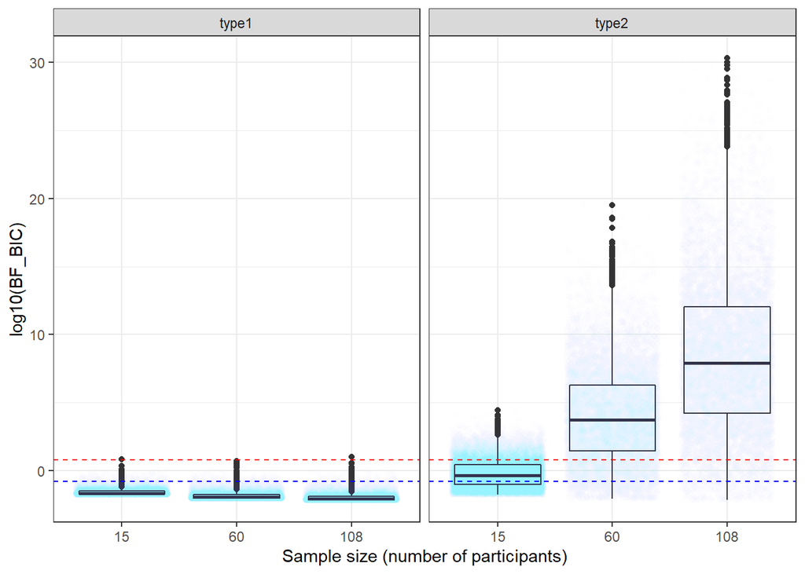

```r
ggplot(sims_BIC, aes(x = factor(Nsubj), y = log10(BF_BIC))) +
  geom_boxplot() +
  geom_jitter(height = 0, alpha = myalpha, colour = jitter_colour) +
  facet_grid(. ~ sim_type) +
  geom_hline(yintercept = log10(6), linetype = "dashed", colour = "red") +
  geom_hline(yintercept = log10(1/6), linetype = "dashed", colour = "blue") +
  xlab("Sample size (number of participants)")
```

In the plot above:

- BFs above the red dashed line ($>6$) lead to accepting the alternative hypothesis (H1);
- BFs below the blue dashed line ($<\frac{1}{6}$) lead to accepting the null hypothesis (H0);
- BFs between the two lines constitute inconclusive evidence.

Below is a numerical summary of the same information:

```r
by(sims_BIC$BF_BIC, with(sims_BIC, list(Nsubj, sim_type)), summary)
```

```
## : 15
## : type1
##    Min. 1st Qu.  Median    Mean 3rd Qu.    Max.
## 0.01787 0.01869 0.02152 0.03538 0.03085 6.81228
## --------------------------------------------------------
## : 60
## : type1
##     Min.  1st Qu.   Median     Mean  3rd Qu.     Max.
## 0.008896 0.009388 0.011132 0.022876 0.016981 5.029155
## --------------------------------------------------------
## : 108
## : type1
##      Min.   1st Qu.    Median      Mean   3rd Qu.      Max.
##  0.006648  0.006988  0.008264  0.018333  0.012480 10.444620
## --------------------------------------------------------
## : 15
## : type2
##      Min.   1st Qu.    Median      Mean   3rd Qu.      Max.
##     0.018     0.094     0.459    18.087     2.706 26609.929
## --------------------------------------------------------
## : 60
## : type2
##      Min.   1st Qu.    Median      Mean   3rd Qu.      Max.
## 0.000e+00 2.900e+01 5.216e+03 4.030e+15 1.961e+06 3.243e+19
## --------------------------------------------------------
## : 108
## : type2
##      Min.   1st Qu.    Median      Mean   3rd Qu.      Max.
## 0.000e+00 1.683e+04 8.240e+07 4.119e+26 1.083e+12 1.968e+30
```

## 6.2 Bayes factor design analysis: How often will we reach the right decision?

Create a figure that summarizes the design analysis. This is the figure used in our report.

```r
plot_sims <- function(type, df = sims_BIC) {
  d <- sims_BIC %>%
    filter(sim_type == type, Nsubj %in% c(15, 60, 108), converged == TRUE) %>%
    select(rseed : Nsubj, BF_BIC) %>%
    unique() %>%
    mutate(BF_decision = ifelse(
      BF_BIC >= 6, "Accept H1", ifelse(
        BF_BIC <= 1/6, "Accept H0", "Inconclusive"))
      ) %>%
    group_by(Nsubj, BF_decision) %>%
    summarise(count = n()) %>%
    mutate(perc = count / sum(count))

  mylevels <- c("Accept H0", "Inconclusive", "Accept H1")
  mycolours <- c("#00AFBB", "#E7B800", "#FC4E07")

  # Some values are assigned depending on whether it's type 1 or 2 simulations
  if (type == "type2") {
    mytitle <- "Type 2 simulations: H1 is true\n(effect is present)"
    yinterc <- 0.9
    } else if (type == "type1") {
      mytitle <- "Type 1 simulations: H0 is true\n(effect is absent)"
      yinterc <- 0.05
      } else {
        stop("Invalid argument for type!")
      }
  d$BF_decision <- factor(d$BF_decision, levels = mylevels)
  # Plot it
  p <- ggplot(d, (aes(x = factor(Nsubj), y = perc, fill = BF_decision))) +
    geom_bar(stat = "identity") +
    # Don't drop unused levels
    scale_fill_manual(values = mycolours, drop = FALSE) +
    geom_hline(yintercept = yinterc, linetype = "dashed") +
    xlab("Number of participants") +
    ylab("Proportion") +
    labs(fill = "Decision") +
    ggtitle(mytitle) +
    theme(legend.position = "bottom")
  p
}
```

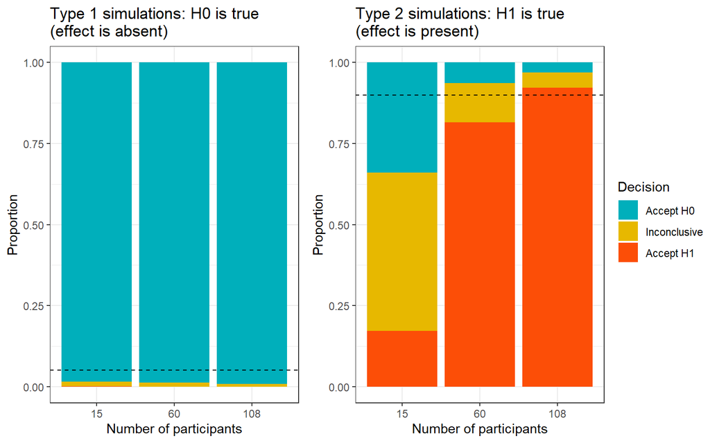

```r
p1 <- plot_sims("type1")
p2 <- plot_sims("type2")
ggarrange(p1, p2, ncol=2, nrow=1, common.legend = TRUE, legend="right")
```

Same information in table format:

```r
sims_BIC %>%
  filter(Nsubj %in% c(15, 60, 108), converged == TRUE) %>%
  select(rseed : Nsubj, BF_BIC) %>%
  unique() %>%
  mutate(BF_decision = ifelse(
    BF_BIC >= 6, "Accept H1", ifelse(
      BF_BIC <= 1/6, "Accept H0", "Inconclusive"))
    ) %>%
  group_by(sim_type, Nsubj, BF_decision) %>%
  summarise(count = n()) %>%
  mutate(percentage = 100 * count / sum(count)) %>%
  kable(digits = 1)
```

| sim_type | Nsubj | BF_decision | count | percentage |
| --- | --- | --- | --- | --- |
| type1 | 15 | Accept H0 | 9873 | 98.5 |
| type1 | 15 | Accept H1 | 2 | 0.0 |
| type1 | 15 | Inconclusive | 145 | 1.4 |
| type1 | 60 | Accept H0 | 9894 | 98.8 |
| type1 | 60 | Inconclusive | 117 | 1.2 |
| type1 | 108 | Accept H0 | 9916 | 99.1 |
| type1 | 108 | Accept H1 | 1 | 0.0 |
| type1 | 108 | Inconclusive | 85 | 0.8 |
| type2 | 15 | Accept H0 | 6427 | 34.0 |
| type2 | 15 | Accept H1 | 3231 | 17.1 |
| type2 | 15 | Inconclusive | 9229 | 48.9 |
| type2 | 60 | Accept H0 | 636 | 6.3 |
| type2 | 60 | Accept H1 | 8199 | 81.5 |
| type2 | 60 | Inconclusive | 1226 | 12.2 |
| type2 | 108 | Accept H0 | 303 | 3.0 |
| type2 | 108 | Accept H1 | 9238 | 92.2 |
| type2 | 108 | Inconclusive | 481 | 4.8 |

## 6.3 Frequentist analysis: Significance of critical coefficients

We can also do a power analysis from the frequentist perspective. To this end, we look at the *z*-values for the critical interaction (in the full models which have the interaction, of course).

The dashed line marks the conventional threshold for significance in frequentist analysis for two-tailed hypotheses (with alpha = .05), namely $z=1.96$.

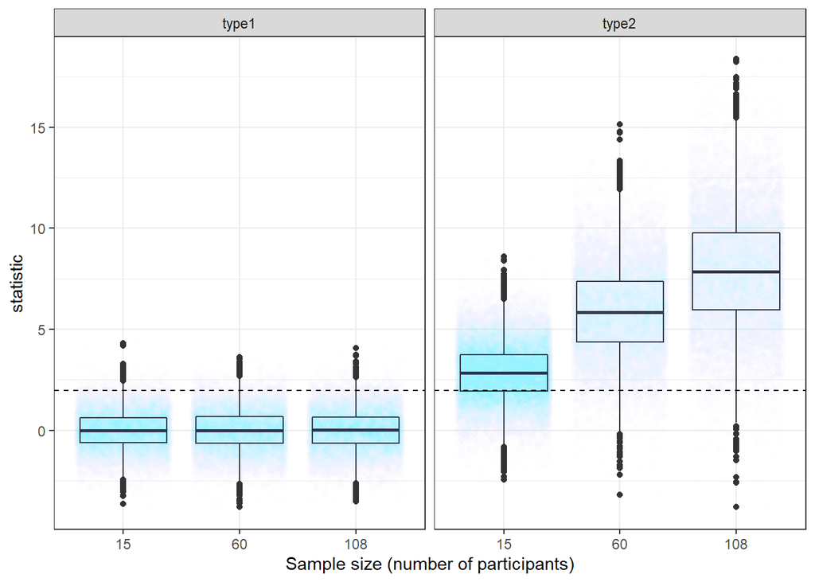

```r
sims_coef %>%
  filter(term == "mv_wt") %>%
  ggplot(aes(x = factor(Nsubj), y = statistic)) +
  geom_boxplot() +
  geom_jitter(height = 0, alpha = myalpha, colour = jitter_colour) +
  facet_grid(. ~ sim_type) +
  geom_hline(yintercept = 1.96, linetype = "dashed") +
  xlab("Sample size (number of participants)")
```

Summary of decisions taken in a table format. In a frequentist framework we either reject the null or fail to reject it. Type 1 simulations show us the rate of false positives; Type 2 simulations show power:

```r
freq_decis <- expand.grid(
  H0_decision = c("Reject", "Fail to reject"),
  sim_type = unique(sims_coef$sim_type)
  ) %>%
  mutate(
    decision = c("correct", "incorrect", "incorrect", "correct" ),
    characterization = c("effect detected", "false negative / type 2 error",
                      "false positive / type 1 error", "no effect")
    )
sims_coef %>%
  filter(term == "mv_wt") %>%
  mutate(H0_decision = ifelse(abs(statistic) > 1.96, "Reject", "Fail to reject")) %>%
  group_by(sim_type, Nsubj, H0_decision) %>%
  summarise(count = n()) %>%
  mutate(percentage = 100 * count / sum(count)) %>%
  left_join(freq_decis) %>%
  select(sim_type : H0_decision, decision, characterization, count, percentage) %>%
  arrange(sim_type, Nsubj, decision, characterization) %>%
  kable(digits = 1)
```

| sim_type | Nsubj | H0_decision | decision | characterization | count | percentage |
| --- | --- | --- | --- | --- | --- | --- |
| type1 | 15 | Fail to reject | correct | no effect | 10241 | 96.5 |
| type1 | 15 | Reject | incorrect | false positive / type 1 error | 374 | 3.5 |
| type1 | 60 | Fail to reject | correct | no effect | 9637 | 95.4 |
| type1 | 60 | Reject | incorrect | false positive / type 1 error | 461 | 4.6 |
| type1 | 108 | Fail to reject | correct | no effect | 9550 | 95.1 |
| type1 | 108 | Reject | incorrect | false positive / type 1 error | 490 | 4.9 |
| type2 | 15 | Reject | correct | effect detected | 14699 | 74.2 |
| type2 | 15 | Fail to reject | incorrect | false negative / type 2 error | 5107 | 25.8 |
| type2 | 60 | Reject | correct | effect detected | 9790 | 96.3 |
| type2 | 60 | Fail to reject | incorrect | false negative / type 2 error | 376 | 3.7 |
| type2 | 108 | Reject | correct | effect detected | 9919 | 98.4 |
| type2 | 108 | Fail to reject | incorrect | false negative / type 2 error | 163 | 1.6 |

Note that the frequentist power analysis for the *same* data are much more lenient. This is particularly noticeable in the power estimates (type 2) for sample sizes of 15.

## 6.4 Sanity check: Are we retrieving the correct estimates?

Since we are simulating the data sets, we *know* what the population-level effects are, both for fixed and random effecs variance. Are our models correctly retrieving them?

Most importantly, the estimates of the population-level effect for the critical interaction:

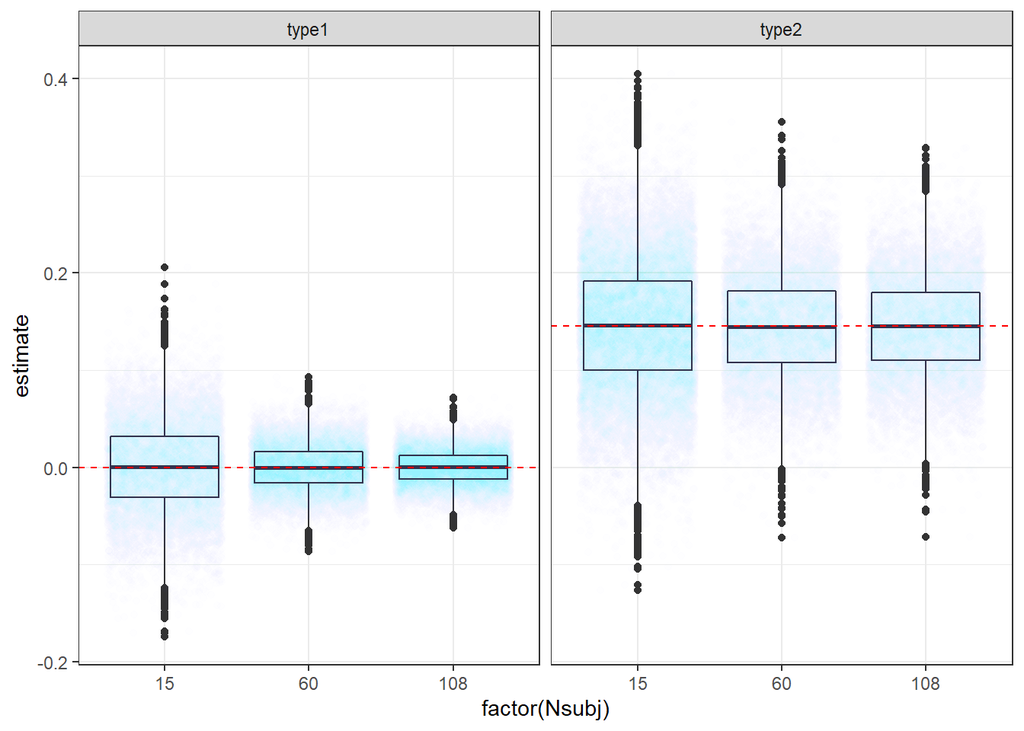

```r
mylines <- tibble(sim_type = unique(sims_coef$sim_type), myy = c(fixef_means[4], 0))
sims_coef %>%
  filter(term == "mv_wt") %>%
  ggplot(aes(x = factor(Nsubj), y = estimate)) +
  geom_boxplot() +
  geom_jitter(height = 0, alpha = myalpha, colour = jitter_colour) +
  facet_grid(. ~ sim_type) +
  geom_hline(data = mylines, aes(yintercept = myy), colour = "red", linetype = "dashed")
```

Estimates of the random by-subject variation for critical effect. Note that these tend to be overestimated, especially in the Type 2 simulations.

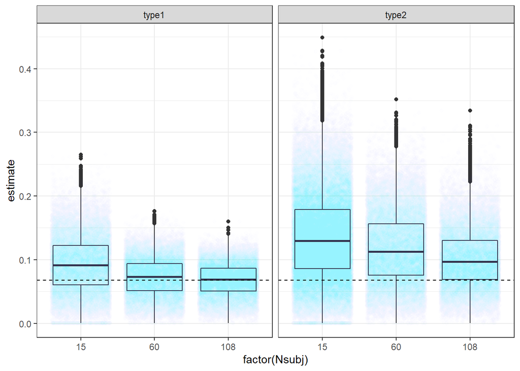

```r
sims_coef %>%
  filter(grepl("sd_mv_wt\\.subject", term)) %>%
  ggplot(aes(x = factor(Nsubj), y = estimate)) +
  geom_boxplot() +
  geom_jitter(height = 0, alpha = myalpha, colour = jitter_colour) +
  facet_grid(. ~ sim_type) +
  geom_hline(yintercept = sqrt(diag(ranef_sigma_subj)[4]), linetype = "dashed")
```

Estimates of the random by-subject variation for the intercept:

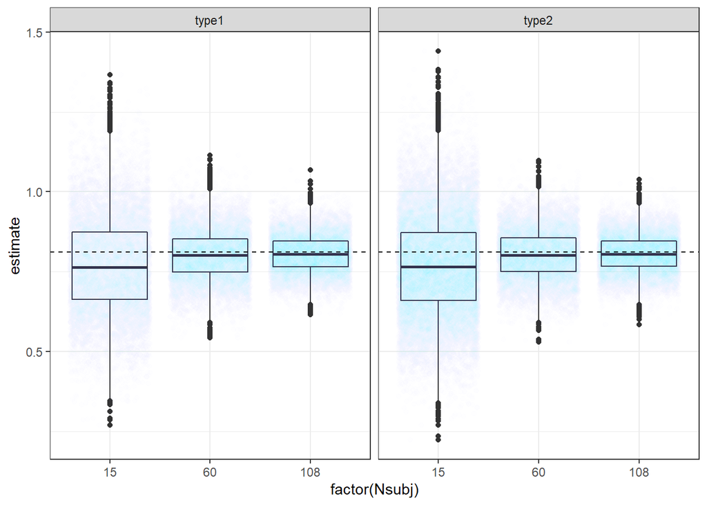

```r
sims_coef %>%
  filter(grepl("sd_\\(Intercept\\).subject", term)) %>%
  ggplot(aes(x = factor(Nsubj), y = estimate)) +
  geom_boxplot() +
  geom_jitter(height = 0, alpha = myalpha, colour = jitter_colour) +
  facet_grid(. ~ sim_type) +
  geom_hline(yintercept = sqrt(diag(ranef_sigma_subj)[1]), linetype = "dashed")
```

# 7 Conclusion

Our proposed design with $N_{min}=60$, $N_{max}=108$ (step size = 12), and the evidence threshold set at $BF_{10} > 6$ or $BF_{01} > 6$ will largely suffice to guarantee high power (>90%) if the effect is as strong as indicated by our improved reanalysis of the original data.

# 8 Appendix: Converged vs non-converged models

We discarded all models that failed to converge or resulted in other model fitting problems. Here we show that these models were *more liberal* in accepting the H1. In other words, our choice of excluding them makes our results more conservative:

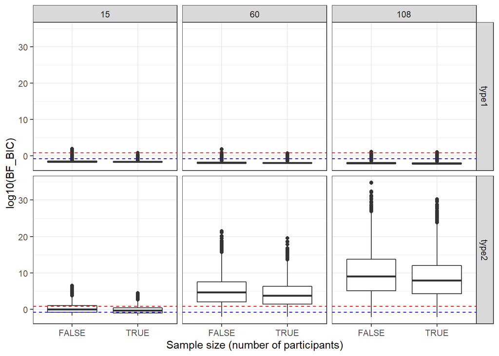

```r
ggplot(sims_BIC_all, aes(x = converged, y = log10(BF_BIC))) +
  geom_boxplot() +
  # geom_jitter(height = 0, alpha = myalpha, colour = jitter_colour) +
  facet_grid(sim_type ~ Nsubj) +
  geom_hline(yintercept = log10(6), linetype = "dashed", colour = "red") +
  geom_hline(yintercept = log10(1/6), linetype = "dashed", colour = "blue") +
  xlab("Sample size (number of participants)")
```

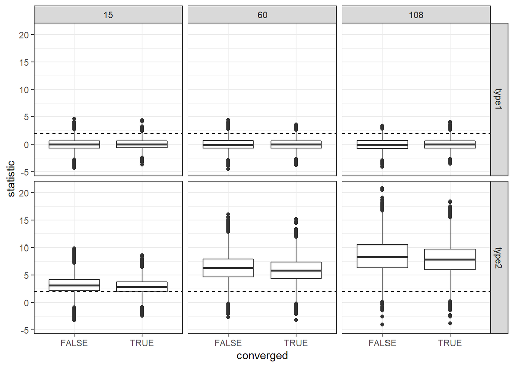

```r
sims_coef_all %>%
  filter(term == "mv_wt") %>%
  ggplot(aes(x = converged, y = statistic)) +
  geom_boxplot() +
  # geom_jitter(height = 0, alpha = myalpha, colour = jitter_colour) +
  facet_grid(sim_type ~ Nsubj) +
  geom_hline(yintercept = 2, linetype = "dashed")
```

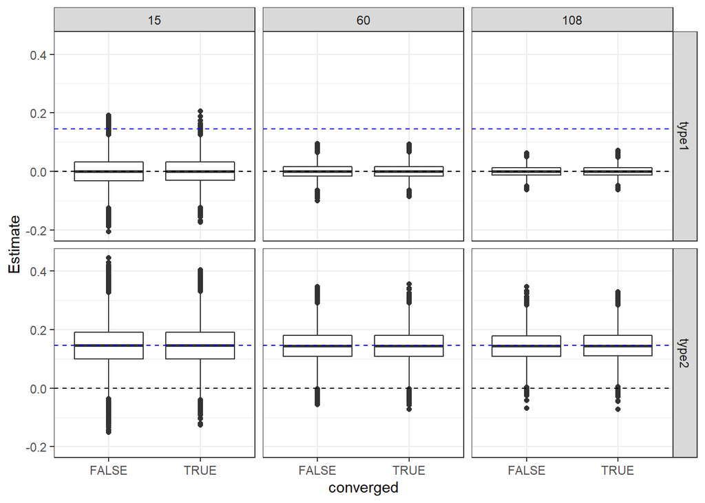

[session information not shown]

```r
sims_coef_all %>%
  filter(term == "mv_wt") %>%
  ggplot(aes(x = converged, y = estimate)) +
  geom_boxplot() +
  # geom_jitter(height = 0, alpha = myalpha, colour = jitter_colour) +
  facet_grid(sim_type ~ Nsubj) +
  geom_hline(yintercept = fixef_means[4], linetype = "dashed", colour = "blue") +
  geom_hline(yintercept = 0, linetype = "dashed") +
  ylab("Estimate")
```